# Project 1: Data Exploration and Visualization

Harper Zhu, in collaboration with Siyue Zhu

Due: 10/26/2020 at the start of class

*As the popularity of board game has been rising up in the recent decades, it became one of the necessary items for friends’ gatherings. As the fun and happiness from playing board games together is irreplaceable, some people felted tempted to invite more to play with them. However, there might be some implicit concerns about if the the more the merrier ringing true in this case. That is, some people may ask, what is the number of maximum players most commonly seen on all board games?*

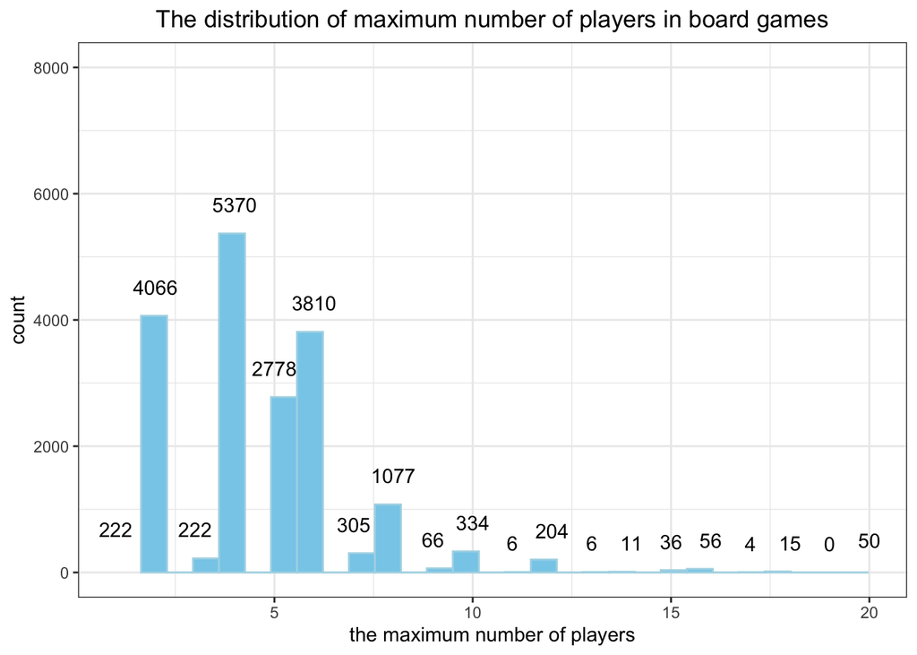

*Sometimes, not all friends and families are available. But the games that people played together often has an intrinsic imprints on people’s preference to board games, and oftentimes make the players addicted to one type of game only. A common concern with this persistence is board games that work well in a small group setting might not work well in large group settings, and vice verse, which might expose people to a sense of frustration when switching settings. But is this really true that games that can be played with a larger number of people will not work well with relatively small number of people? In another words,is there really a correlation between the maximum players and smaller players?*

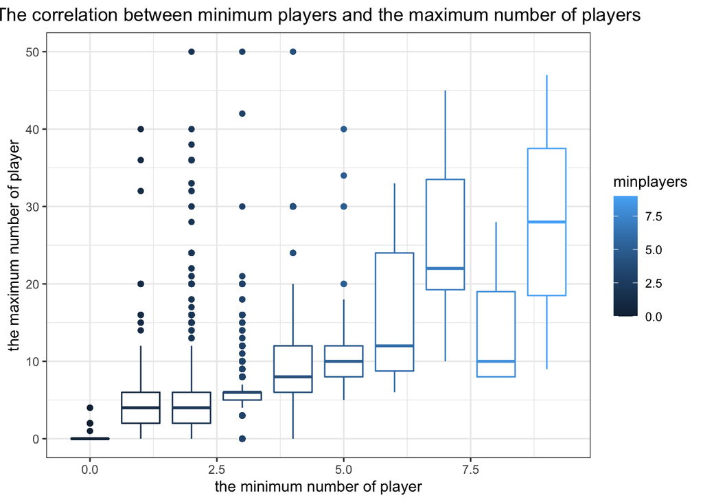

*We can see from the graph that the larger the minimum number of players the game require, generally, the median of the maximum player also increases. Also, the range from the first quantile to the third quantile also increases with the number of minimum players increase. We can conclude that the minimum number of player and maximum of player has a positive correlation, which supports our previous guessing and we can say that board games can be divided to different sizes associating with different group size.*

*Given the popularity of board games, it is natural for people to be curious when did all those board games published.*

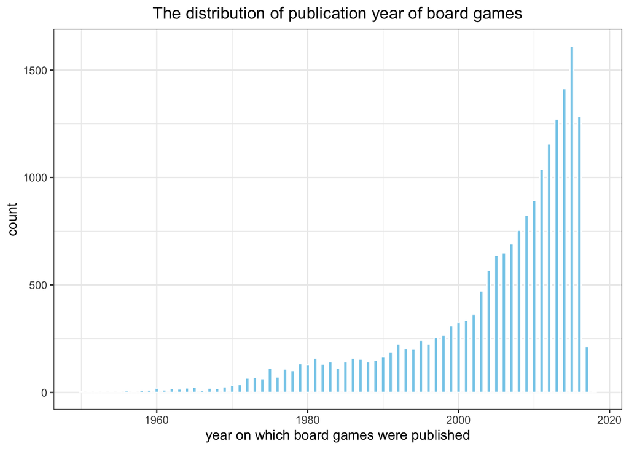

*It seems like board games became more and more popular, and the number of new board games are created with an increasing speed. Especially, the number of publication increased sharply especially after 2000. However, after 2015, the number decreases, which does not consistent with our expectation. I think this abnormal decrease is interesting and we can do further research on this topic. One potential reason I can think for now is there might be something wrong with our data set, we may lose some data after year 2015. Another reason might be young people are not interested in playing board games, they may prefer to play electronics instead of board games.*

*As the number of board games published each years before 2015 are increasing, some people expect there to be an sense of competition within all publishers to increase their sales. One way of doing that is to increase the complexity of the game to keep people on the hook. Is this really true that the year published affects the average complexity of the game?*

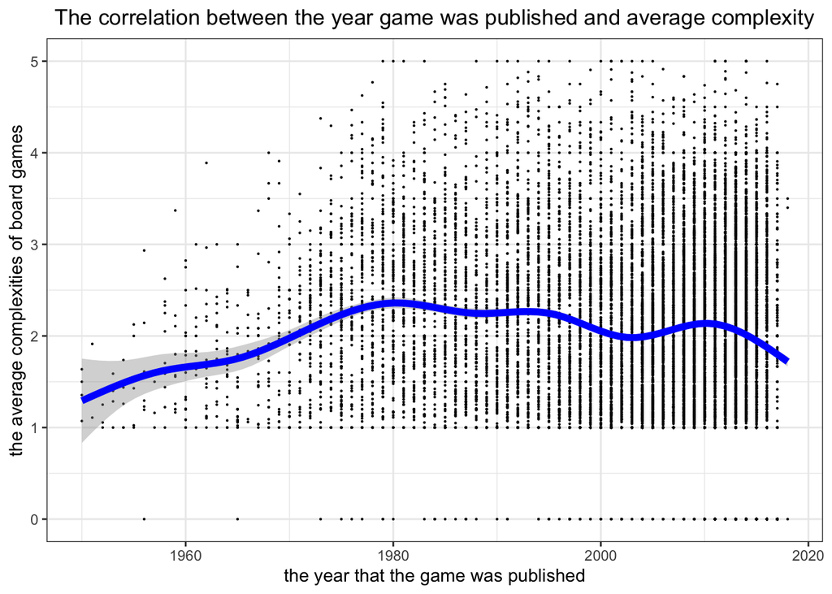

*The trend of the average complexity increase then decrease with time goes on. We can see the average complexity increases before 1980 and decreases after 1980, which reaches a peak at 1980. This does not consistent with our expectation that the average complexity increases with the number of publication increases. Board games designers might realized that games with relative low average complexity are more popular than games with high average complexity. Designers are willing to create board games with lower complexity since players are intended to easier games.*

*On the other hand, leaving alone the effect of publication date, many board game lovers are thrilled to look for games with higher level of average complexity. Here, we can divide up the games into categories and ask What is the top 15 categories of board games with the highest level of average complexity.*

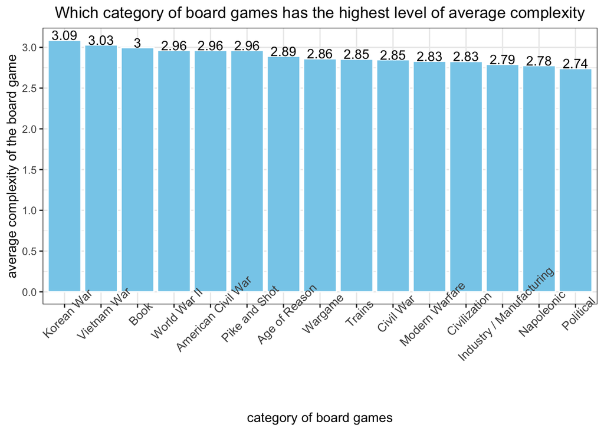

*While some fans might be excited about the increase of average complexity, others are worried about the increase of average complexities can have a negative impact on the average rating of the board games.*

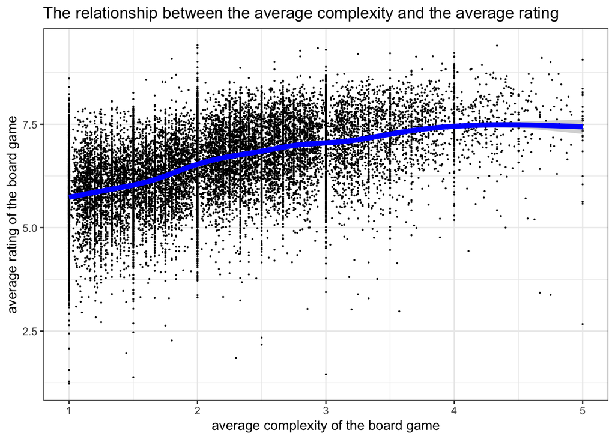

*The average complexities of the board game do not have a negative impact on the average rating of the board games. In fact, the graph shows that there is a positive correlation between average complexity and average rating.*

*According to board games, there are many intuitive conclusion such as minimum players and maximum players have the positive correlation. However, there also exist counter-intuitive facts. For example, the number of publication is not always increasing, many boards are designed for a small of people, and the higher average complexity does lead to higher rating. It is interesting to dig deep into data to find out these fun facts.*

# Appendix: All code for this report

```r
#Code for the first graph

library(dplyr)
library(ggplot2)
#read the csv data from an online csv file
board_game_original<- read.csv("https://raw.githubusercontent.com/bryandmartin/STAT302/master/docs/Projects/project1_bgdataviz/board_game_raw.csv")
#set board_game as a csv file and filter out games that are earlier than 1950 and have less than 25 ratings.
board_game <- as.data.frame.matrix(board_game_original)
filtered_data <- board_game %>%
                filter(yearpublished >= 1950, users_rated >= 25)

#Draw a histogram to show the distribution of maximum number of players
maxplayers_graph<- ggplot(data=filtered_data, aes(x =maxplayers)) +
        #set the histogram bar as light blue and fill it with sky blue
        geom_histogram(color="light blue",fill="sky blue") +
        #label each bar with the number of counts
        stat_bin(binwidth=1, geom="text", aes(label=..count..), vjust=-1.5) +
        #set the x scale to from 1 to 20
        xlim(1,20) +
        #set the y scale to  from 0 to 80000
        ylim(0,8000) +
        #set the theme to black and white
        theme_bw() +
        #set the title of the graph
        ggtitle("The distribution of maximum number of players in board games")+
        #center the title of the graph
        theme(plot.title = element_text(hjust = 0.5)) +
        #set the caption of x axis
        xlab("the maximum number of players") +
        #set the caption of y axis
        ylab("count")
maxplayers_graph

#Code for the second graph

#Draw the graph with minplayers as the x variable and maxplayers as the y variable
minplayers_maxplayers_graph <- ggplot(data = filtered_data, aes(x = minplayers, y = maxplayers, group = minplayers, color = minplayers, na.rm = TRUE)) +
        #Draw the boxplot
        geom_boxplot() +
        #Change the limit for the y axis
        ylim(0, 50) +
        #set the theme to black and white
        theme_bw() +
        #Add a title to the graph
        ggtitle("The correlation between minimum players and the maximum number of players") +
        #Adjust the tile
        theme(plot.title = element_text(hjust = 0.5)) +
        #Add the caption for x axis
        xlab("the minimum number of player") +
        #Add the caption for y axis
        ylab("the maximum number of player")
minplayers_maxplayers_graph

#Code for the third graph

#Draw the graph with filtered_data as the variable
yearpublished_graph <- ggplot(data = filtered_data, aes(yearpublished)) +
        #Draw the histogram
        geom_histogram(binwidth=0.5, color = "white", fill="sky blue") +
        #Change the theme for the graph
        theme_bw() +
        #Add a title to the graph
        ggtitle("The distribution of publication year of board games") +
        #Adjust the tile
        theme(plot.title = element_text(hjust = 0.5)) +
        #Add the label for x axis
        xlab("year on which board games were published") +
        #Add the label for y axis
        ylab("count")
yearpublished_graph

#Code for the fourth graph

#Draw the graph with maxplaytime as the x variable and average_complexity as the y              variable
maxplaytime_average_complexity_graph <- ggplot(data = filtered_data, aes(x = yearpublished, y = average_complexity)) +
            #Draw the point plot
            geom_point(size = 0.1) +
            #Add a trend line for the graph
            geom_smooth(color="blue", size=2) +
            #ylim(0, 10000) +
            # Change the theme for the graph
            theme_bw() +
            #Add a title to the graph
            ggtitle("The correlation between the year game was published and average complexity") +
            #Adjust the tile
            theme(plot.title = element_text(hjust = 0.5)) +
            #Add the label for x axis
            xlab("the year that the game was published") +
            #Add the label for y axis
            ylab("the average complexities of board games")
maxplaytime_average_complexity_graph

#Code for the fifth graph

#tidy up the column of mechanic and category with cSplit function
library(splitstackshape)
board_game_tidy <- cSplit(board_game,splitCols=c("mechanic","category"), sep = ",", direction = "long")

#use piping to isolate all the category and average complexity from board_game_tidy under conditions
library(dplyr)
new_category_complexity <- board_game_tidy %>%
            filter(average_complexity > 0, yearpublished >= 1950, users_rated >= 25) %>%
            select(category, average_complexity) %>%
            group_by(category)
#eliminate all the NA in new_category_complexity
new_category_complexity <- na.omit(new_category_complexity)
#use piping to takes the mean of average complexity from rows with identical category and arrange category in descending order of mean complexity
new_category_complexity <- new_category_complexity %>%
                           group_by(category) %>%
                           mutate(my_average = mean(average_complexity)) %>%
                           select(-average_complexity) %>%
                           distinct()
#take the top 15 category with the highest mean complexity from
top15_average <- new_category_complexity %>%
                arrange(desc(my_average)) %>%
                head(15)
#Plot the relationship between the top 15 category with the highest level of average complexity
#create a bar graph
category_complexity_graph <- ggplot(data=top15_average, aes(x = reorder(category, -my_average), y = my_average, na.rm = TRUE)) +
        geom_bar(stat = "identity",position = 'dodge', na.rm = TRUE, color="white",fill="sky blue") +
        #set the scale of y-axis to a range of 0 to 3.5
        ylim(0,3.5) +
        #set the break unit of the y-axis to be 0.5 to show smaller difference
        scale_y_continuous(breaks=seq(0, 3.5, 0.5)) +
        # label the values in the top of bars
        geom_text(aes(label=round(my_average, digits = 2)), position=position_dodge(width=0.005), vjust = -0.05, hjust=0.5) +
        #set the background to be black and white
        theme_bw() +
        #set the title of the graph
        ggtitle("Which category of board games has the highest level of average complexity") +
        #set the caption of the x axis
        xlab("category of board games") +
        #set the caption of the y axis
        ylab("average complexity of the board game") +
        #set the size and angle of the categorical variable in x axis
        theme(axis.text.x = element_text(size=10,angle = 45)) +
        #center the title of the graph
        theme(plot.title = element_text(hjust = 0.5))
category_complexity_graph

#Code for the sixth graph

#filter out datapoints whose average_complexity=0 and extract all board games with the non-zero average_complexity
board_game_without_0 <- filtered_data %>%
        select(average_complexity,average_rating) %>%
        filter(average_complexity > 0)
#Plot out the relationship between the average complexity and average ratings
#set average_complexity as as x and average_rating as y
rating_complexity_graph<- ggplot(data=board_game_without_0, aes(x = average_complexity, y = average_rating)) +
        #use point graphs of size 0.1
        geom_point(size=0.1) +
        #Add a trendline of size 2 and color blue
        geom_smooth(color="blue", size=2, method = "gam", formula = y ~ s(x, bs = "cs")) +
        #set the title of the graph
        ggtitle("The relationship between the average complexity and the average rating") +
        #set the title of the x axis
        xlab("average complexity of the board game") +
        #set the title of the y axis
        ylab("average rating of the board game") +
        #center the title of the graph
        theme(plot.title = element_text(hjust = 0.5)) +
        #set the theme as black and white
        theme_bw()
rating_complexity_graph
```